# Language models as research tools: Potentials and pitfalls when studying hate speech

Methods festival 2023

Aleksi Knuutila

aleksi.knuutila@helsinki.fi

JYU, HY

August 31, 2023

Slides available at: http://knuutila.net/mf2023

## A bit about me

- University researcher in Helsinki (Sociology) and Jyväskylä (Culture studies)
- Working on information environment in Ukraine, hate speech in Finland
- Interested in critical and creative use of machine learning in social sciences

## Structure of presentation

1. What are large language models (“LLMs”)
2. Challenges in hate speech research
3. Examples of my own research and novel uses of LLMs
4. Concluding summary

# What are large language models (LLMs)

## What are large language models (LLMs)

### Examples of large language models

[figure not shown]

- Google Bert, 2017
- OpenAI’s ChatGPT, 2022
- Meta’s Llama-2, 2023

## What are large language models (LLMs)

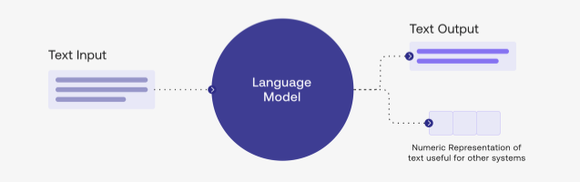

### Definitions

- LLMs model text and can be used to generate it
- LLMs receive large-scale **pretraining**
- LLMs make inferences based on **transfer learning**

Source: Luccioni, Alexandra Sasha, and Anna Rogers. “Mind Your Language (Model): Fact-Checking LLMs and Their Role in NLP Research and Practice.”

## What are large language models (LLMs)

### A change in researcher workflow

|  | Training your own model | Text analysis with LLMs |
| --- | --- | --- |
| **Models used** | Researcher experiments with a range of model types specific to the task | Choosing a pre-trained LLM which may work on several tasks |
| **Preparing model** | Training model exclusively on your data | Model has been pre-trained on large corpus, finetune on your own data |

- LLMs are like *swiss army knives*, a decent solution for many tasks
- A potential simplification in expertise required for modeling - but at a cost!

# Challenges in hate speech research

## Challenges in hate speech detection

### Creating your dataset

- “Hate speech” definitions vary, and researchers often adopt context-specific concepts (eg. extreme speech, harmful speech, othering speech, nethate)
- Low inter-coder reliability in coding (eg. about 70% on HASOC)
- Bias in training data, for instance minority slang more often labelled as hate speech

## Challenges in hate speech detection

### Models won’t replace human readers

- Core challenge is finding analytical concepts that
  1. Provide analytical value, i.e. reveal something insightful about data
  2. Are clear enough so that several readers agree on how to apply them
  3. Can be operationalised with models such as LLMs
- Agreement between people is proxy for validity of concepts
- Finding right concepts may require many attempts
  - LLMs may make iterative process easier

# Two concrete examples

## Research with Cabinet office

[figure not shown]

## Definition of “hateful speech”

[figure not shown]

**hateful speech**: Messages that

1. Contains slur from pre-defined list
2. Use slurs used in abusive or threatening way

## Finetuning a model in Python

```
model = AutoModelForSequenceClassification.from_pretrained(
    "TurkuNLP/bert-base-finnish-uncased-v1"
)

training_args = TrainingArguments(
    "nethate", evaluation_strategy="epoch", logging_steps=30
)
metric = load_metric("accuracy")

trainer = Trainer(
    args=training_args,
    model=model,
    train_dataset=train_dataset,
    eval_dataset=eval_dataset,
    compute_metrics=compute_metrics,
)
trainer.train()

finetuned_finbert = pipeline(
    model=model, tokenizer=tokenizer, task="sentiment-analysis", return_all_scores=True
)
```

Goal: A “boring”, boilerplate model

Source: https://github.com/AleksiKnuutila/nethate_classifier/

## An alternative workflow: zero-shot annotation

- Can be done with LLMs that are trained to be directed with prompts
- Zero-shot: When the model is asked to perform a task that it hasn’t specifically been trained on, i.e. to apply new categories that are described to it
- Results tend to be worse, but perhaps good enough for experimenting with concepts?

Source: Pangakis et al. “Automated Annotation with Generative AI Requires Validation”

## Example of zero-shot annotation

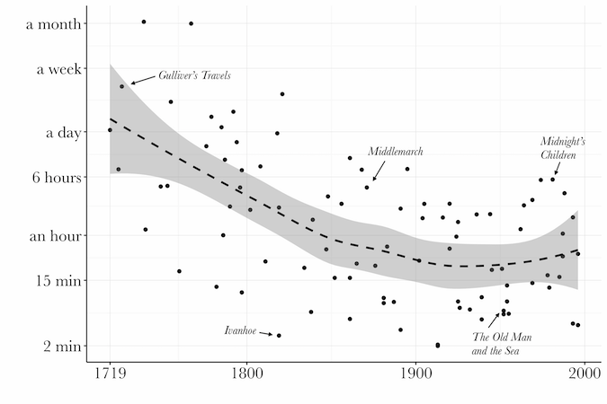

An example of annotating text: Assessing the amount of time passing in literary passages.

Source: Underwood, “Why Literary Time is Measured in Minutes”

## Prompting GPT-4 to read fiction

### Instructions in natural language

```
Read the following passage of fiction. Then do five things.

1. Reason step by step to decide how much time is described in the passage. If the
passage doesn't include any explicit reference to time, you can guess how much
time the events described would have taken.

2. ...

The passage follows: ...
```

Source: https://tedunderwood.com/2023/03/19/using-gpt-4-to-measure-the-passage-of-time-in-fiction/

## Prompting GPT-4 to read fiction

### Results

```
Making coffee, showering, and getting dressed take at least an hour. There's
some ambiguity about whether to count the implicit reference to yesterday
(since this is 'the next morning') as time elapsed in the passage, but let's
say no, since yesterday is not actually described. So, an hour to 90 minutes.
```

In the future, a way to pilot analysis with natural language prompts?

# Summary and conclusions

## Conclusions

- Challenge of finding right analytical concepts particularly prevalent in hate speech research
- Previously the high cost of modelling meant concept development done on subset of data, before modelling
- LLMs may reduce cost of modelling and make it easier to iteratively read large datasets with novel concepts
- LLMs introduce their own ethical issues and dependencies

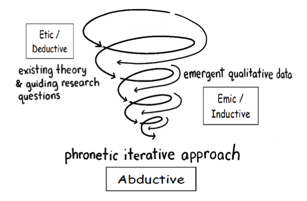

Source: Tracy, “A Phronetic Iterative Approach to Data Analysis in Qualitative Research”

## Thanks! Questions and feedback appreciated

aleksi.knuutila@helsinki.fi

http://knuutila.net/mf2023